## Tarea 2

Programa Experto en Inteligencia Artificial con Python  
ML2000 - Métodos No Supervisados  
Estudiante: Natalia Bonilla Villalobos.

# Menú

- Ejercicio 1
- Ejercicio 2

```python
pip install prince
```

```python
import numpy as np
import pandas as pd
import seaborn as sns
import matplotlib.pyplot as plt
from math import pi
from prince import PCA as pca_prince
from sklearn.preprocessing import StandardScaler
from sklearn.preprocessing import MinMaxScaler
from scipy.spatial.distance import pdist, squareform
from scipy.cluster.hierarchy import ward, single, complete, average
from scipy.cluster.hierarchy import dendrogram, linkage, fcluster
from itertools import cycle
```

# Ejercicio 1

[70 puntos] Utilice el conjunto de datos `StressLevel.csv`. Este conjunto contiene información obtenida de una encuesta a estudiantes universitarios, con el objetivo de identificar factores asociados al estrés académico. La tabla cuenta con N filas (estudiantes) y 20 variables descritas a continuación:

- **Factores psicológicos:**
  - `anxiety_level`: Nivel de ansiedad reportado. Escala numerica discreta (mayores valores = más ansiedad).
  - `self_esteem`: Nivel de autoestima. Escala numerica discreta (valores altos = mayor autoestima).
  - `mental_health_history`: Antecedentes de salud mental (0 = No, 1 = Sí). Variable categórica binaria.
  - `depression`: Puntaje de síntomas depresivos. Numerica discreta (valores altos = mayor depresión).
- **Factores fisiológicos:**
  - `headache`: Frecuencia de dolores de cabeza. Categórica ordinal (0 = nunca, 5 = muy frecuente).
  - `blood_pressure`: Nivel de presión arterial. Categórica ordinal (1 = baja, 2 = normal, 3 = alta).
  - `sleep_quality`: Calidad del sueño. Categórica ordinal (0 = muy mala, 5 = muy buena).
  - `breathing_problem`: Presencia de problemas respiratorios. Categórica ordinal (0 = nunca, 5 = muy frecuente).
- **Factores ambientales:**
  - `noise_level`: Nivel de ruido en el entorno. Categórica ordinal (0 = bajo, 5 = muy alto).
  - `living_conditions`: Condiciones de vida del estudiante. Categórica ordinal (0 = muy malas, 5 = muy buenas).
  - `safety`: Percepción de seguridad en el entorno. Categórica ordinal (0 = nada seguro, 5 = muy seguro).
  - `basic_needs`: Grado de satisfacción de necesidades básicas (alimentación, vivienda). Categórica ordinal (0 = insatisfechas, 5 = totalmente satisfechas).
- **Factores académicos:**
  - `academic_performance`: Confianza en el rendimiento académico. Categórica ordinal (0 = muy baja, 5 = muy alta).
  - `study load`: Percepción de la carga académica. Categórica ordinal (0 = muy ligera, 5 = muy pesada).
  - `teacher_student_relationship`: Calidad de la relación con los profesores. Categórica ordinal (0 = muy mala, 5 = muy buena).
  - `future_career_concerns`: Preocupación por la carrera futura. Categórica ordinal (0 = nada preocupado, 5 = muy preocupado).
- **Factores sociales:**
  - `social_support`: Nivel de apoyo social percibido. Categórica ordinal (0 = muy bajo, 5 = muy alto).
  - `peer_pressure`: Presión ejercida por los pares. Categórica ordinal (0 = nula, 5 = muy alta).
  - `extracurricular_activities`: Participación en actividades extracurriculares. Categórica ordinal (0 = nula, 5 = muy alta).
  - `bullying`: Presencia de acoso escolar. Categórica ordinal (0 = nunca, 5 = muy frecuente).
- **Variable objetivo:**
  - `stress_type`: Tipo de estrés que experimenta principalmente el estudiante. Variable categórica con tres clases posibles: No Stress = 0, Eustress = 1, Distress = 2.

**Realice lo siguiente:**

1. Convertir la variable `mental_health_history` a numérica, asegurando que pueda ser utilizada en los cálculos de distancia.
2. Normalizar las variables numéricas para que estén en la misma escala. Esto evita que algunas variables dominen sobre otras en el cálculo de distancias.
3. Genere el Clustering Jerárquico con un número fijo de 4 clusters, utilizando:
- Tres tipos de distancia (por ejemplo: Euclidiana, Manhattan y Gower).
- Cuatro métodos de enlace (linkage): *single*, *complete*, *average*, *ward*.  
  En total deben generarse 12 modelos de clustering jerárquico.
4. Para cada uno de los 12 modelos de Clustering Jerárquico formados anteriormente seleccione la mejor formación según la inercia (intra-clase o inter-clase).
5. Brinde una característica de cada cluster utilizando el gráfico de barras.
6. Brinde una característica de cada cluster utilizando el gráfico radar.
7. Analice la distribución de la variable categórica `stress_level` dentro de los clusters. Para ello construya un gráfico de barras con la proporción de cada tipo de estrés en los clusters e interprete los resultados.

↑ Volver al Menú

```python
df = pd.read_csv('StressLevel.csv')
df.head()
```

|  | anxiety_level | self_esteem | mental_health_history | depression | headache | blood_pressure | sleep_quality | breathing_problem | noise_level | living_conditions | ... | basic_needs | academic_performance | study_load | teacher_student_relationship | future_career_concerns | social_support | peer_pressure | extracurricular_activities | bullying | stress_level |
| --- | --- | --- | --- | --- | --- | --- | --- | --- | --- | --- | --- | --- | --- | --- | --- | --- | --- | --- | --- | --- | --- |
| 0 | 14 | 20 | 0 | 11 | 2 | 1 | 2 | 4 | 2 | 3 | ... | 2 | 3 | 2 | 3 | 3 | 2 | 3 | 3 | 2 | 1 |
| 1 | 15 | 8 | 1 | 15 | 5 | 3 | 1 | 4 | 3 | 1 | ... | 2 | 1 | 4 | 1 | 5 | 1 | 4 | 5 | 5 | 2 |
| 2 | 12 | 18 | 1 | 14 | 2 | 1 | 2 | 2 | 2 | 2 | ... | 2 | 2 | 3 | 3 | 2 | 2 | 3 | 2 | 2 | 1 |
| 3 | 16 | 12 | 1 | 15 | 4 | 3 | 1 | 3 | 4 | 2 | ... | 2 | 2 | 4 | 1 | 4 | 1 | 4 | 4 | 5 | 2 |
| 4 | 16 | 28 | 0 | 7 | 2 | 3 | 5 | 1 | 3 | 2 | ... | 3 | 4 | 3 | 1 | 2 | 1 | 5 | 0 | 5 | 1 |

5 rows × 21 columns

```python
df.shape
```

```
(1100, 21)
```

```python
df_cod = df.copy()
```

## Parte 1

Convertir la variable mental_health_history a numérica, asegurando que pueda ser utilizada en los cálculos de distancia.

```python
# mental_health_history =  0:No, 1:Si
df_cod[['mental_health_history_no','mental_health_history_si']] = pd.get_dummies(df_cod['mental_health_history'], dtype=int)
df_cod[['mental_health_history', 'mental_health_history_si','mental_health_history_no']].head()
```

|  | mental_health_history | mental_health_history_si | mental_health_history_no |
| --- | --- | --- | --- |
| 0 | 0 | 0 | 1 |
| 1 | 1 | 1 | 0 |
| 2 | 1 | 1 | 0 |
| 3 | 1 | 1 | 0 |
| 4 | 0 | 0 | 1 |

```python
df_cod.shape
```

```
(1100, 23)
```

```python
#No Stress = 0, Eustress = 1, Distress = 2.
df_cod[['stress_type_no_stress','stress_type_eustress', 'stress_type_distress']] = pd.get_dummies(df_cod['stress_level'], dtype=int)
df_cod[['stress_level', 'stress_type_no_stress','stress_type_eustress', 'stress_type_distress']].head(7)
# df_cod.head()
```

|  | stress_level | stress_type_no_stress | stress_type_eustress | stress_type_distress |
| --- | --- | --- | --- | --- |
| 0 | 1 | 0 | 1 | 0 |
| 1 | 2 | 0 | 0 | 1 |
| 2 | 1 | 0 | 1 | 0 |
| 3 | 2 | 0 | 0 | 1 |
| 4 | 1 | 0 | 1 | 0 |
| 5 | 2 | 0 | 0 | 1 |
| 6 | 0 | 1 | 0 | 0 |

```python
df_cod.shape
```

```
(1100, 26)
```

```python
df_cod = df_cod.drop(columns=['mental_health_history', 'stress_level'], axis=1)
```

```python
df_cod.columns
```

```
Index(['anxiety_level', 'self_esteem', 'depression', 'headache',
       'blood_pressure', 'sleep_quality', 'breathing_problem', 'noise_level',
       'living_conditions', 'safety', 'basic_needs', 'academic_performance',
       'study_load', 'teacher_student_relationship', 'future_career_concerns',
       'social_support', 'peer_pressure', 'extracurricular_activities',
       'bullying', 'mental_health_history_no', 'mental_health_history_si',
       'stress_type_no_stress', 'stress_type_eustress',
       'stress_type_distress'],
      dtype='object')
```

```python
df_cod.shape
```

```
(1100, 24)
```

## Parte 2

Normalizar las variables numéricas para que estén en la misma escala. Esto evita que algunas variables dominen sobre otras en el cálculo de distancias.

```python
scale = StandardScaler()
df_cod_scaled = scale.fit_transform(df_cod)
df_cod_scaled = pd.DataFrame(df_cod_scaled)
```

```python
df_cod_scaled.head()
```

|  | 0 | 1 | 2 | 3 | 4 | 5 | 6 | 7 | 8 | 9 | ... | 14 | 15 | 16 | 17 | 18 | 19 | 20 | 21 | 22 | 23 |
| --- | --- | --- | --- | --- | --- | --- | --- | --- | --- | --- | --- | --- | --- | --- | --- | --- | --- | --- | --- | --- | --- |
| 0 | 0.480208 | 0.248612 | -0.201393 | -0.360741 | -1.418416 | -0.426445 | 0.890211 | -0.488949 | 0.430695 | 0.186924 | ... | 0.229550 | 0.112839 | 0.186334 | 0.164249 | -0.403377 | 0.985559 | -0.985559 | -0.716287 | 1.439662 | -0.710484 |
| 1 | 0.643746 | -1.093590 | 0.316508 | 1.768859 | 0.981981 | -1.072574 | 0.890211 | 0.264334 | -1.357096 | -0.524551 | ... | 1.537869 | -0.841952 | 0.888277 | 1.575763 | 1.557071 | -1.014653 | 1.014653 | -0.716287 | -0.694608 | 1.407491 |
| 2 | 0.153131 | 0.024912 | 0.187033 | -0.360741 | -1.418416 | -0.426445 | -0.538282 | -0.488949 | -0.463200 | 0.186924 | ... | -0.424609 | 0.112839 | 0.186334 | -0.541508 | -0.403377 | -1.014653 | 1.014653 | -0.716287 | 1.439662 | -0.710484 |
| 3 | 0.807284 | -0.646189 | 0.316508 | 1.058992 | 0.981981 | -1.072574 | 0.175964 | 1.017616 | -0.463200 | -0.524551 | ... | 0.883709 | -0.841952 | 0.888277 | 0.870006 | 1.557071 | -1.014653 | 1.014653 | -0.716287 | -0.694608 | 1.407491 |
| 4 | 0.807284 | 1.143414 | -0.719293 | -0.360741 | 0.981981 | 1.511942 | -1.252529 | 0.264334 | -0.463200 | 0.898398 | ... | -0.424609 | -0.841952 | 1.590220 | -1.953023 | 1.557071 | 0.985559 | -0.985559 | -0.716287 | 1.439662 | -0.710484 |

5 rows × 24 columns

```python
df_cod_scaled.columns = df_cod.columns
df_cod_scaled.index = df_cod.index
df_cod_scaled.head()
```

|  | anxiety_level | self_esteem | depression | headache | blood_pressure | sleep_quality | breathing_problem | noise_level | living_conditions | safety | ... | future_career_concerns | social_support | peer_pressure | extracurricular_activities | bullying | mental_health_history_no | mental_health_history_si | stress_type_no_stress | stress_type_eustress | stress_type_distress |
| --- | --- | --- | --- | --- | --- | --- | --- | --- | --- | --- | --- | --- | --- | --- | --- | --- | --- | --- | --- | --- | --- |
| 0 | 0.480208 | 0.248612 | -0.201393 | -0.360741 | -1.418416 | -0.426445 | 0.890211 | -0.488949 | 0.430695 | 0.186924 | ... | 0.229550 | 0.112839 | 0.186334 | 0.164249 | -0.403377 | 0.985559 | -0.985559 | -0.716287 | 1.439662 | -0.710484 |
| 1 | 0.643746 | -1.093590 | 0.316508 | 1.768859 | 0.981981 | -1.072574 | 0.890211 | 0.264334 | -1.357096 | -0.524551 | ... | 1.537869 | -0.841952 | 0.888277 | 1.575763 | 1.557071 | -1.014653 | 1.014653 | -0.716287 | -0.694608 | 1.407491 |
| 2 | 0.153131 | 0.024912 | 0.187033 | -0.360741 | -1.418416 | -0.426445 | -0.538282 | -0.488949 | -0.463200 | 0.186924 | ... | -0.424609 | 0.112839 | 0.186334 | -0.541508 | -0.403377 | -1.014653 | 1.014653 | -0.716287 | 1.439662 | -0.710484 |
| 3 | 0.807284 | -0.646189 | 0.316508 | 1.058992 | 0.981981 | -1.072574 | 0.175964 | 1.017616 | -0.463200 | -0.524551 | ... | 0.883709 | -0.841952 | 0.888277 | 0.870006 | 1.557071 | -1.014653 | 1.014653 | -0.716287 | -0.694608 | 1.407491 |
| 4 | 0.807284 | 1.143414 | -0.719293 | -0.360741 | 0.981981 | 1.511942 | -1.252529 | 0.264334 | -0.463200 | 0.898398 | ... | -0.424609 | -0.841952 | 1.590220 | -1.953023 | 1.557071 | 0.985559 | -0.985559 | -0.716287 | 1.439662 | -0.710484 |

5 rows × 24 columns

## Parte 3

Genere el Clustering Jerárquico con un número fijo de 4 clusters, utilizando:

- Tres tipos de distancia (por ejemplo: Euclidiana, Manhattan y Gower).
- Cuatro métodos de enlace (linkage): single, complete, average, ward.  
  En total deben generarse 12 modelos de clustering jerárquico.

```python
def calc_distancias(df, metric_method):
  if metric_method == 'euclidean':
    return pdist(df, metric = metric_method)
  elif metric_method == 'chebyshev':
    return pdist(df, metric = metric_method)
  elif metric_method == 'canberra':
    return pdist(df, metric = metric_method)
```

### Euclidean

**Distancia Euclidean**

```python
calc_distancias(df_cod_scaled, "euclidean")
```

```
array([ 7.0339876 ,  3.62678465,  6.44775314, ..., 10.22600538,
        8.80727973,  4.44693484])
```

**Agregación Euclidean**

```python
# Salto Minimo
agregacion_single_euclidean = single(calc_distancias(df_cod_scaled, "euclidean"))

# Salto Maximo
agregacion_complete_euclidean = complete(calc_distancias(df_cod_scaled, "euclidean"))

# Salto Promedio
agregacion_average_euclidean = average(calc_distancias(df_cod_scaled, "euclidean"))

# Salto Ward
agregacion_ward_euclidean = ward(calc_distancias(df_cod_scaled, "euclidean"))
```

### Chebyshev

**Distancia Chebyshev**

```python
distancia_chebyshev = calc_distancias(df_cod_scaled, "chebyshev")
```

**Agregación Chebyshev**

```python
# Salto Minimo
agregacion_single_chebyshev = single(distancia_chebyshev)

# Salto Maximo
agregacion_complete_chebyshev = complete(distancia_chebyshev)

# Salto Promedio
agregacion_average_chebyshev = average(distancia_chebyshev)

# Salto Ward
agregacion_ward_chebyshev = ward(distancia_chebyshev)
```

### Canberra

**Distancia Canberra**

```python
distancia_canberra = pdist(df_cod_scaled, metric = "canberra")
distancia_canberra
```

```
array([18.78119548, 10.33427579, 19.27818641, ..., 23.        ,
       20.4838426 ,  8.78730782])
```

**Agregación Canberra**

```python
# Salto Minimo
agregacion_single_canberra = single(distancia_canberra)

# Salto Maximo
agregacion_complete_canberra = complete(distancia_canberra)

# Salto Promedio
agregacion_average_canberra = average(distancia_canberra)

# Salto Ward
agregacion_ward_canberra = ward(distancia_canberra)
```

### **Dendograma**

```python
def plt_dendrograma(agregacion, df):
  fig, ax = plt.subplots(1, 1, figsize = (12,8))
  no_print = dendrogram(agregacion, labels = df.index.tolist(), ax = ax)
  plt.show()
```

### **Dendograma Euclidean**

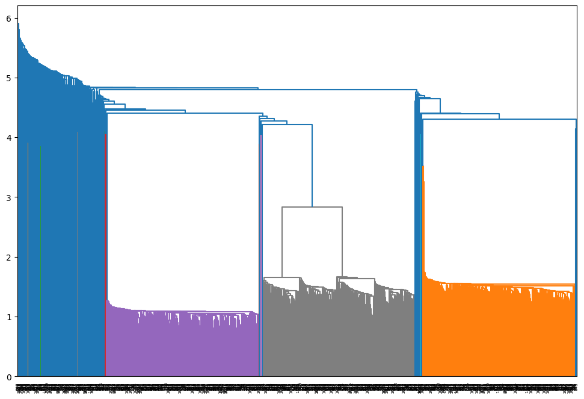

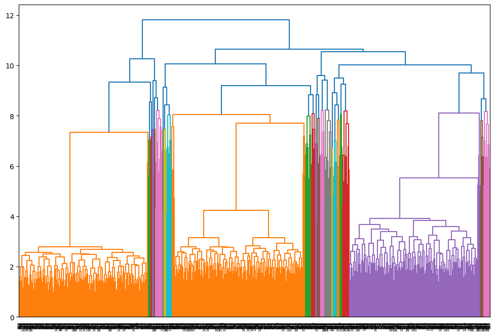

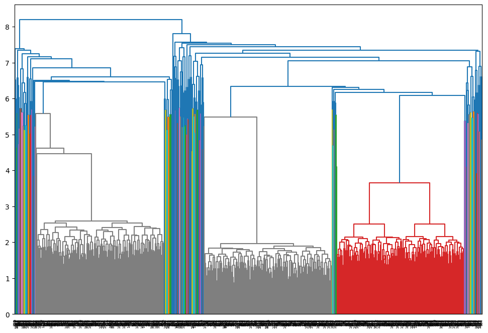

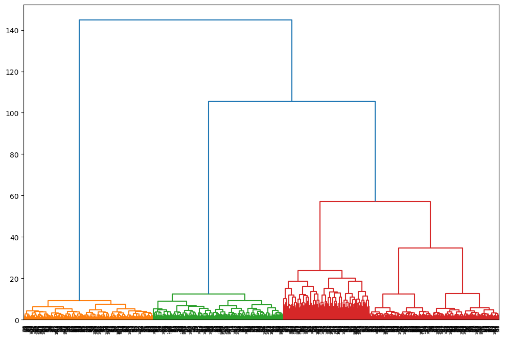

```python
# Linkage Method: single/Min
plt_dendrograma(agregacion_single_euclidean, df_cod_scaled)

# Linkage Method: Complete/Max
plt_dendrograma(agregacion_complete_euclidean, df_cod_scaled)

# Linkage Method: Average/Prom.
plt_dendrograma(agregacion_average_euclidean, df_cod_scaled)

# Linkage Method: Ward.
plt_dendrograma(agregacion_ward_euclidean, df_cod_scaled)
```

### **Dendograma Chebyshev**

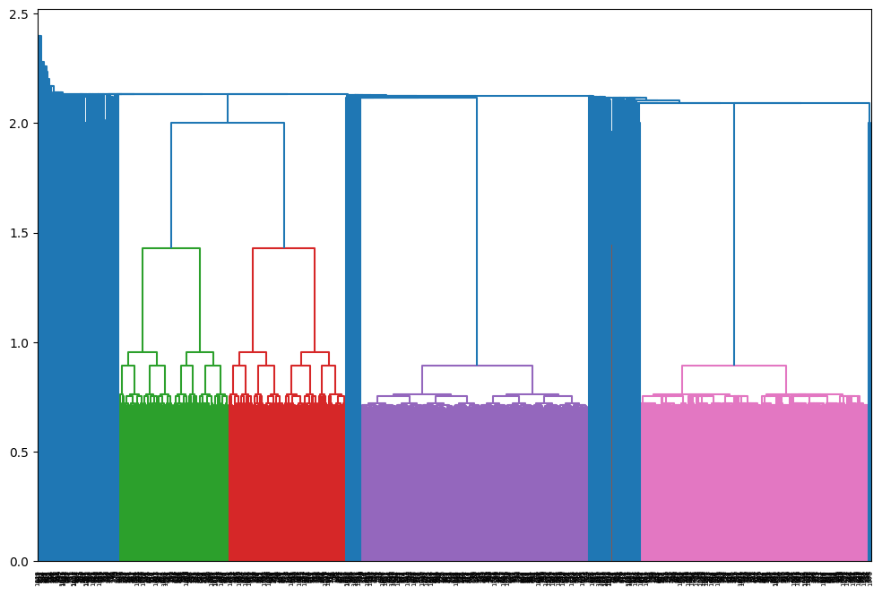

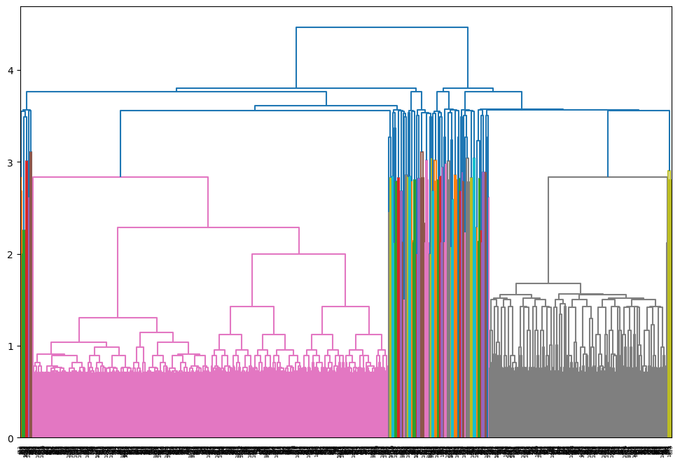

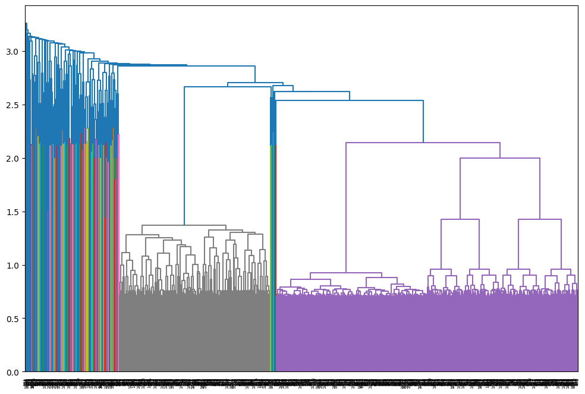

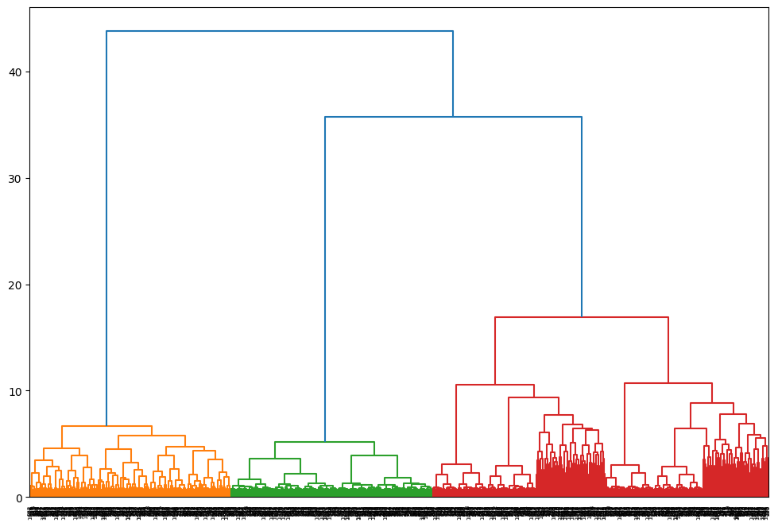

```python
# Linkage Method: single/Min
plt_dendrograma(agregacion_single_chebyshev, df_cod_scaled)

# Linkage Method: Complete/Max
plt_dendrograma(agregacion_complete_chebyshev, df_cod_scaled)

# Linkage Method: Average/Prom.
plt_dendrograma(agregacion_average_chebyshev, df_cod_scaled)

# Linkage Method: Ward.
plt_dendrograma(agregacion_ward_chebyshev, df_cod_scaled)
```

### **Dendograma Canberra**

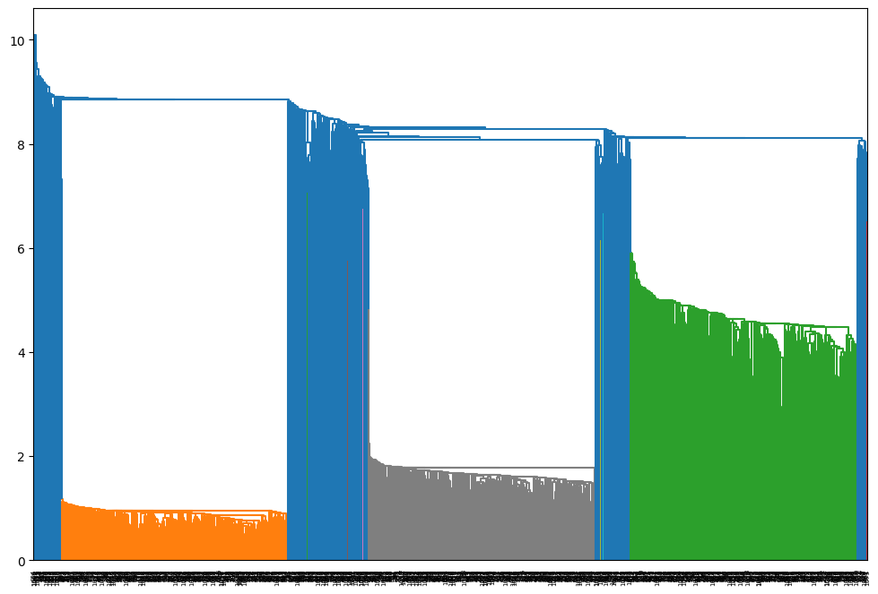

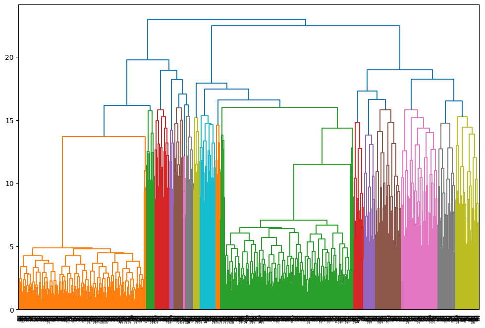

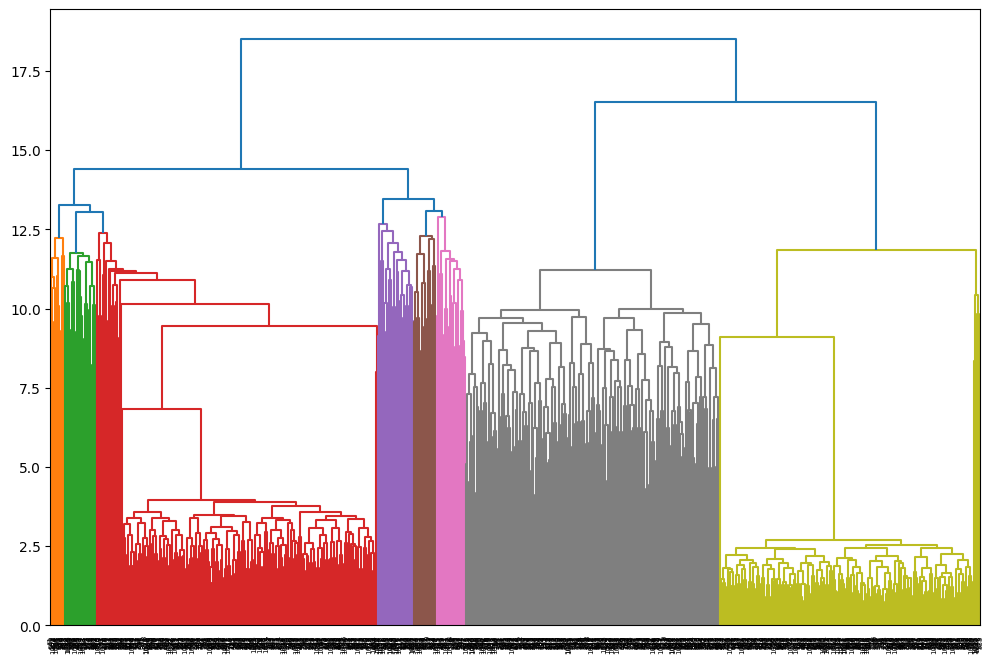

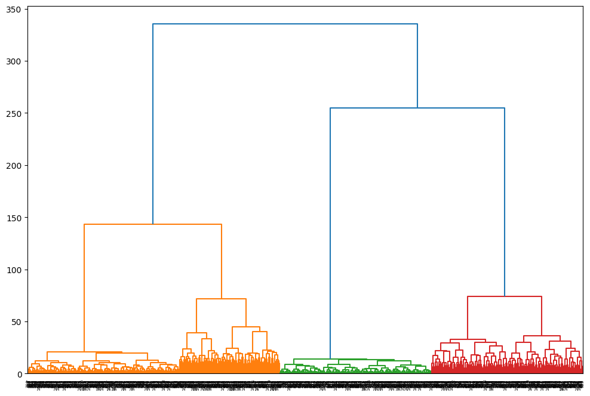

```python
# Linkage Method: single/Min
plt_dendrograma(agregacion_single_canberra, df_cod_scaled)

# Linkage Method: Complete/Max
plt_dendrograma(agregacion_complete_canberra, df_cod_scaled)

# Linkage Method: Average/Prom.
plt_dendrograma(agregacion_average_canberra, df_cod_scaled)

# Linkage Method: Ward.
plt_dendrograma(agregacion_ward_canberra, df_cod_scaled)
```

## Parte 4

Para cada uno de los 12 modelos de Clustering Jerárquico formados anteriormente seleccione la mejor formación según la inercia (intra-clase o inter-clase).

```python
def clusteres(agregacion, nombre):
  grupos = fcluster(agregacion, 4, criterion = 'maxclust')
  grupos = grupos - 1
  print(grupos)
  print(f'Clusters por {nombre}: {len(np.unique(grupos))}')
```

```python
print("========== Euclidean ==========")
# agrupaciones linkage Method: single/Min
clusteres(agregacion_single_euclidean, "Salto Minimo")

# agrupaciones linkage Method: Complete/Max
clusteres(agregacion_complete_euclidean, "Salto Maximo")

# agrupaciones linkage Method: Average/Prom.
clusteres(agregacion_average_euclidean, "Salto Promedio")

# agrupaciones linkage Method: Ward.
clusteres(agregacion_ward_euclidean, "Salto Ward")
```

```
========== Euclidean ==========
[0 0 0 ... 0 0 0]
Clusters por Salto Minimo: 4
[1 3 1 ... 0 3 3]
Clusters por Salto Maximo: 4
[3 0 3 ... 3 0 0]
Clusters por Salto Promedio: 4
[3 1 3 ... 0 1 2]
Clusters por Salto Ward: 4
```

```python
print("========== Chebyshev ==========")
# agrupaciones linkage Method: single/Min
clusteres(agregacion_single_chebyshev, "Salto Minimo")

# agrupaciones linkage Method: Complete/Max
clusteres(agregacion_complete_chebyshev, "Salto Maximo")

# agrupaciones linkage Method: Average/Prom.
clusteres(agregacion_average_chebyshev, "Salto Promedio")

# agrupaciones linkage Method: Ward.
clusteres(agregacion_ward_chebyshev, "Salto Ward")
```

```
========== Chebyshev ==========
[0 0 0 ... 0 0 0]
Clusters por Salto Minimo: 4
[0 3 0 ... 0 3 3]
Clusters por Salto Maximo: 4
[1 1 1 ... 1 1 1]
Clusters por Salto Promedio: 4
[3 0 2 ... 1 0 2]
Clusters por Salto Ward: 4
```

```python
print("========== Canberra ==========")
# agrupaciones linkage Method: single/Min
clusteres(agregacion_single_canberra, "Salto Minimo")

# agrupaciones linkage Method: Complete/Max
clusteres(agregacion_complete_canberra, "Salto Maximo")

# agrupaciones linkage Method: Average/Prom.
clusteres(agregacion_average_canberra, "Salto Promedio")

# agrupaciones linkage Method: Ward.
clusteres(agregacion_ward_canberra, "Salto Ward")
```

```
========== Canberra ==========
[0 0 0 ... 0 0 0]
Clusters por Salto Minimo: 4
[3 2 3 ... 0 2 2]
Clusters por Salto Maximo: 4
[2 0 2 ... 3 0 0]
Clusters por Salto Promedio: 4
[3 0 3 ... 2 0 1]
Clusters por Salto Ward: 4
```

## Funcion de inercias con distncia, agregacion y cluster

```python
def inercias(df_scalar, nombre_linkage, df_dummy, nombre_metric, nombre_inercia):
  # distancia = pdist(df_scalar, metric = nombre_metric)
  # agregacion = nombre_linkage(distancia)
  # grupos = fcluster(agregacion, 3, criterion = 'maxclust')
  # grupos = grupos - 1
  # datos_cluster = df_cod.copy()
  # datos_cluster["cluster"] = grupos

  # promedios = datos_cluster.groupby("cluster").mean()

  # intra_clase = 0
  # for i in range(df_dummy.shape[0]):
  #   intra_clase = intra_clase + np.sum((df_dummy.iloc[i, :] - promedios.iloc[grupos[i], :]) ** 2)

  # return intra_clase

    distancia = pdist(df_scalar, metric = nombre_metric)
    agregacion = nombre_linkage(distancia)
    grupos = fcluster(agregacion, 4, criterion = 'maxclust')
    grupos = grupos - 1
    datos_cluster = df_cod.copy()
    datos_cluster["cluster"] = grupos

    promedios = datos_cluster.groupby("cluster").mean()

    if nombre_inercia.lower() == 'intra':
      intra_clase = 0
      for i in range(df_dummy.shape[0]):
        intra_clase = intra_clase + np.sum((df_dummy.iloc[i, :] - promedios.iloc[grupos[i], :]) ** 2)
      return round(intra_clase, 3)
    elif nombre_inercia.lower() == 'inter':
      promedios_total = df_cod.mean()
      inter_clase = 0
      for i in range(promedios.shape[0]):
        n = np.sum(grupos == i)
        inter_clase = inter_clase + (n * np.sum((promedios_total - promedios.iloc[i, :]) ** 2))
      return round(inter_clase, 3)
    elif nombre_inercia.lower() == 'total':
      promedios_total = df_dummy.mean()
      inercia_total = 0
      for i in range(df_dummy.shape[0]):
        inercia_total = inercia_total + np.sum((df_dummy.iloc[i, :] - promedios_total) ** 2)
      return round(inercia_total, 3)
    else:
      print("Revise los parametros de la funcion")
```

```python
# distancia_ward_euclidean = pdist(df_cod_scaled, metric = 'euclidean')
# agregacion_ward_euclidean = ward(distancia_ward_euclidean)
# grupo_ward_euclidean = fcluster(agregacion_ward_euclidean, 3, criterion = 'maxclust')
# grupo_ward_euclidean = grupo_ward_euclidean - 1
# datos_cluster = df_cod.copy()
# datos_cluster["cluster"] = grupo_ward_euclidean
# # datos_cluster #imprimir tabla

# promedios = datos_cluster.groupby("cluster").mean()

# intra_clase_ward_euclidean =0
# for i in range(df_cod.shape[0]):
#   intra_clase_ward_euclidean = intra_clase_ward_euclidean + np.sum((df_cod.iloc[i, :] - promedios.iloc[grupo_ward_euclidean[i], :]) ** 2)
# intra_clase_ward_euclidean
```

### **Inercias**

```python
def imprimir_inercia_detallada(df_cod_scaled, df_cod, linkages, distancias, nombre_linkages):
    """
    Calcula e imprime los valores de inercia para diferentes
    tipos de linkage y distancias.

    Args:
        df_cod_scaled (DataFrame): DataFrame con datos escalados.
        df_cod (DataFrame): DataFrame con datos originales.
        linkages (list): Lista de objetos de linkage (e.g., [ward, single, ...]).
        distancias (list): Lista de nombres de distancias (e.g., ['euclidean', 'chebyshev', ...]).
        nombre_linkages (list): Lista de nombres de los linkages (e.g., ['Ward', 'Single', ...]).
    """
    tipos_inercia = ['intra', 'inter'] #,total]

    for distancia_nombre in distancias:
        print(f"\n======= Tipo de Inercia | linkage | distancia =======")

        for i, linkage_obj in enumerate(linkages):
            linkage_nombre = nombre_linkages[i]
            # print(f"======================= {linkage_nombre} =======================")

            for tipo_inercia in tipos_inercia:
                valor_inercia = inercias(df_cod_scaled, linkage_obj, df_cod, distancia_nombre, nombre_inercia=tipo_inercia)
                print(f"Inercia Clase-{tipo_inercia.capitalize()} | {linkage_nombre} | {distancia_nombre.capitalize()}: {valor_inercia}")
            print()
```

```python
# inercias(df_cod_scaled, ward, df_cod, 'euclidean', nombre_inercia = 'intra')
# distancia_ward_euclidean = pdist(df_cod_scaled, metric = 'euclidean')
# agregacion_ward_euclidean = ward(distancia_ward_euclidean)
# clusteres(agregacion_ward_euclidean, "Salto Minimo")


# print("======================= Ward ======================= ")
# print(f"Inercia Clase-Intra | Ward | Euclidean: {inercias(df_cod_scaled, ward, df_cod, 'euclidean', nombre_inercia = 'intra')}")
# print(f"Inercia Clase-Inter | Ward | Euclidean: {inercias(df_cod_scaled, ward, df_cod, 'euclidean', nombre_inercia = 'inter')}\n")
# # print(f"Inercia Clase-Total | Ward | Euclidean: {inercias(df_cod_scaled, ward, df_cod, 'euclidean', nombre_inercia = 'total')}\n")

# print("======================= Single ======================= ")
# print(f"Inercia Clase-Intra | Single | Euclidean: {inercias(df_cod_scaled, single, df_cod, 'euclidean', nombre_inercia = 'intra')}")
# print(f"Inercia Clase-Inter | Single | Euclidean: {inercias(df_cod_scaled, single, df_cod, 'euclidean', nombre_inercia = 'inter')}\n")
# # print(f"Inercia Clase-Total | Single | Euclidean: {inercias(df_cod_scaled, single, df_cod, 'euclidean', nombre_inercia = 'total')}\n")

# print("======================= Complete ======================= ")
# print(f"Inercia Clase-Intra | Complete | Euclidean: {inercias(df_cod_scaled, complete, df_cod, 'euclidean', nombre_inercia = 'intra')}")
# print(f"Inercia Clase-Inter | Complete | Euclidean: {inercias(df_cod_scaled, complete, df_cod, 'euclidean', nombre_inercia = 'inter')}\n")
# # print(f"Inercia Clase-Total | Complete | Euclidean: {inercias(df_cod_scaled, complete, 2df_cod, 'euclidean', nombre_inercia = 'total')}\n")

# print("======================= Average ======================= ")
# print(f"Inercia Clase-Intra | Average | Euclidean: {inercias(df_cod_scaled, average, df_cod, 'euclidean', nombre_inercia = 'intra')}")
# print(f"Inercia Clase-Inter | Average | Euclidean: {inercias(df_cod_scaled, average, df_cod, 'euclidean', nombre_inercia = 'inter')}\n")
# # print(f"Inercia Clase-Total | Average | Euclidean: {inercias(df_cod_scaled, average, df_cod, 'euclidean', nombre_inercia = 'total')}\n")
```

```python
linkages = [ward, single, complete, average]
nombre_linkages = ['Ward', 'Single', 'Complete', 'Average']
distancias = ['euclidean', 'chebyshev', 'canberra']

imprimir_inercia_detallada(df_cod_scaled, df_cod, linkages, distancias, nombre_linkages)
```

```
======= Tipo de Inercia | linkage | distancia =======
Inercia Clase-Intra | Ward | Euclidean: 71368.519
Inercia Clase-Inter | Ward | Euclidean: 157075.931

Inercia Clase-Intra | Single | Euclidean: 227634.802
Inercia Clase-Inter | Single | Euclidean: 809.648

Inercia Clase-Intra | Complete | Euclidean: 90889.947
Inercia Clase-Inter | Complete | Euclidean: 137554.503

Inercia Clase-Intra | Average | Euclidean: 118119.756
Inercia Clase-Inter | Average | Euclidean: 110324.694


======= Tipo de Inercia | linkage | distancia =======
Inercia Clase-Intra | Ward | Chebyshev: 75741.568
Inercia Clase-Inter | Ward | Chebyshev: 152702.882

Inercia Clase-Intra | Single | Chebyshev: 227401.582
Inercia Clase-Inter | Single | Chebyshev: 1042.868

Inercia Clase-Intra | Complete | Chebyshev: 114628.491
Inercia Clase-Inter | Complete | Chebyshev: 113815.959

Inercia Clase-Intra | Average | Chebyshev: 227619.511
Inercia Clase-Inter | Average | Chebyshev: 824.939


======= Tipo de Inercia | linkage | distancia =======
Inercia Clase-Intra | Ward | Canberra: 71368.519
Inercia Clase-Inter | Ward | Canberra: 157075.931

Inercia Clase-Intra | Single | Canberra: 228067.573
Inercia Clase-Inter | Single | Canberra: 376.877

Inercia Clase-Intra | Complete | Canberra: 88906.157
Inercia Clase-Inter | Complete | Canberra: 139538.293

Inercia Clase-Intra | Average | Canberra: 85550.342
Inercia Clase-Inter | Average | Canberra: 142894.108
```

## **Comparación:** **Euclidean/Canberra**

Buscar MÍNIMA inercia intra-clase (dentro del cluster)  
Buscar MÁXIMA inercia inter-clase (entre clusters)

Inercia Clase-Intra | Ward | **Euclidean**: 71,368.519  
Inercia Clase-Inter | Ward | Euclidean: 157,075.931  
Inercia Clase-Intra | Ward | **Canberra**: 71,368.519  
Inercia Clase-Inter | Ward | Canberra: 157,075.931

```python
mejor_agregacion = agregacion_ward_canberra
grupos_definitivos = fcluster(mejor_agregacion, 4, criterion='maxclust') - 1

print("=== CLUSTERS DEFINITIVOS ===")
print("Distribución de puntos por cluster:")
print(pd.Series(grupos_definitivos).value_counts().sort_index())

# Añadir clusters al dataframe
df_con_clusters = df_cod.copy()
df_con_clusters['cluster'] = grupos_definitivos
```

```
=== CLUSTERS DEFINITIVOS ===
Distribución de puntos por cluster:
0    301
1    199
2    300
3    300
Name: count, dtype: int64
```

```python
grupos_definitivos
```

```
array([3, 0, 3, ..., 2, 0, 1], dtype=int32)
```

## Parte 5

Brinde una característica de cada cluster utilizando el gráfico de barras.

```python
def graficar_barras_promedios(promedios):
    """
    Grafica un barplot de promedios por clúster.

    Parámetros
    ----------
    promedios : pandas.DataFrame
        DataFrame resultante de agrupar por 'cluster' y promediar.
        - El índice debe ser el nombre/ID del clúster.
        - Las columnas son las variables (materias).
    """
    fig, ax = plt.subplots(figsize=(15, 8))  # tamaño por defecto
    no_print = promedios.plot(kind='bar', ax=ax)
    no_print = ax.set_xlabel('Clúster', fontsize=12)
    no_print = ax.set_ylabel('Promedio', fontsize=12)
    no_print = ax.legend(title="Factores", title_fontsize=13, fontsize=11, loc='upper right', bbox_to_anchor=(1.26, 1))
    plt.show()
```

[figure not shown]

```python
promedios_clusters = df_con_clusters.groupby('cluster').mean()
graficar_barras_promedios(promedios_clusters)
```

**CARACTERIZACIÓN DE CLUSTERS**

- Cluster 0:
  - Variables mas altas: **`depression`**, `anxiety_level`, & `self_esteem`.
  - Variables mas bajas: **`mental_healt_history_no`**, `stess_type_no_stress`, `stess_type_eustress`
- Cluster 1:
  - Variables mas altas: **`self_esteem`**, `depression`, & `anxiety_level`.
  - Variables mas bajas: **`stess_type_eustress`**, `stess_type_distress`, `stess_type_no_stress`.
- Cluster 2:
  - Variables mas altas: **`self_esteem`**, `safety`, & `academic_performance`.
  - Variables mas bajas: **`mental_healt_history_si`**, `stess_type_eustress`, & `stess_type_disstress`.
- Cluster 3:
  - Variables mas altas: **`self_esteem`**, `depression`, & `anxiety_level`.
  - Variables mas bajas: **`stess_type_no_stress`**,`stess_type_distress`, `future_career_concerns`.

## Parte 6

Brinde una característica de cada cluster utilizando el gráfico radar.

```python
def graficar_radar_promedios(promedios):
    """
    Grafica un radar chart (polar) para los promedios por clúster.

    Parámetros
    ----------
    promedios : pandas.DataFrame
        DataFrame con índice = clústeres y columnas = variables.
    """
    # Escalado 0-100
    scaler = MinMaxScaler()
    escalar_promedios = pd.DataFrame(
        scaler.fit_transform(promedios),
        columns=promedios.columns,
        index=promedios.index
    )
    escalar_promedios = escalar_promedios * 100
    columnas = escalar_promedios.columns
    N = len(columnas)
    # Ángulos (cerrando el polígono)
    theta = np.linspace(0, 2 * np.pi, N, endpoint=False)
    theta = np.concatenate([theta, [theta[0]]])
    fig, ax = plt.subplots(figsize=(12, 14), subplot_kw={"projection": "polar"})
    no_print = ax.set_theta_zero_location("N")
    no_print = ax.set_theta_direction(-1)
    no_print = ax.set_rlabel_position(90)
    no_print = ax.spines["polar"].set_zorder(1)
    no_print = ax.spines["polar"].set_color("lightgrey")
    # Trazar cada clúster
    for fila in escalar_promedios.index:
        valores = escalar_promedios.loc[fila, columnas].values.tolist()
        valores = valores + [valores[0]]  # cerrar polígono
        no_print = ax.plot(theta, valores, linewidth=1.75, linestyle="solid",
                           label=f"Cluster {fila}", marker="o", markersize=10)
        no_print = ax.fill(theta, valores, alpha=0.50)
    # Ejes y leyendas
    no_print = plt.yticks([0, 25, 50, 75, 100], ["0", "25", "50", "75", "100"], color="black", size=12)
    no_print = plt.ylim(-10, 100)
    no_print = plt.xticks(theta, columnas.to_list() + [columnas[0]], color="black", size=12)
    no_print = plt.legend(loc="upper right", bbox_to_anchor=(1.3, 1.1))
    plt.show()
```

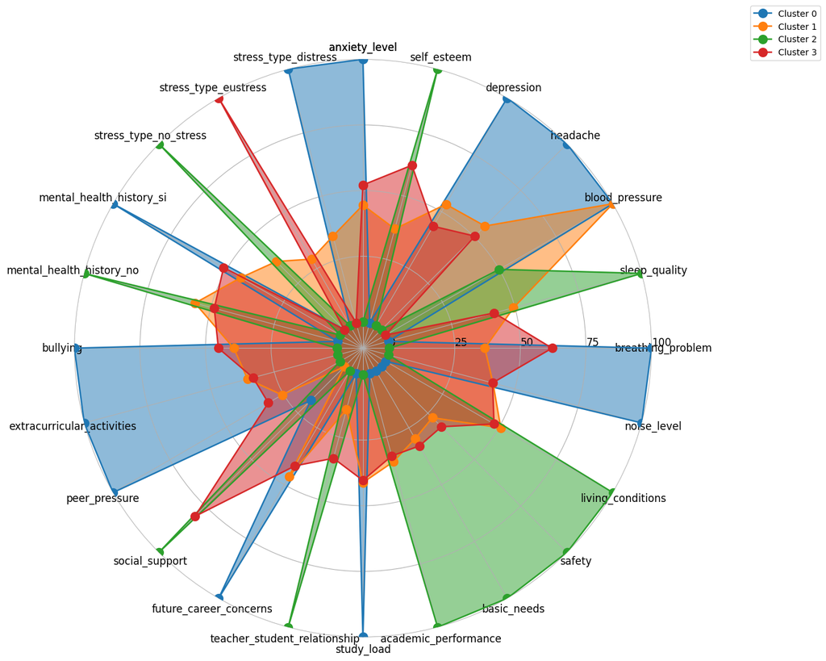

```python
graficar_radar_promedios(promedios_clusters)
```

## Parte 7

Analice la distribución de la variable categórica `stress_level` dentro de los clusters. Para ello construya un gráfico de barras con la proporción de cada tipo de estrés en los clusters e interprete los resultados.

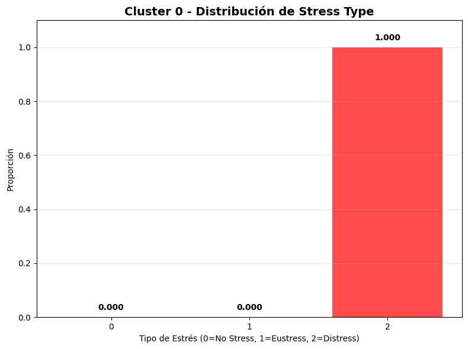

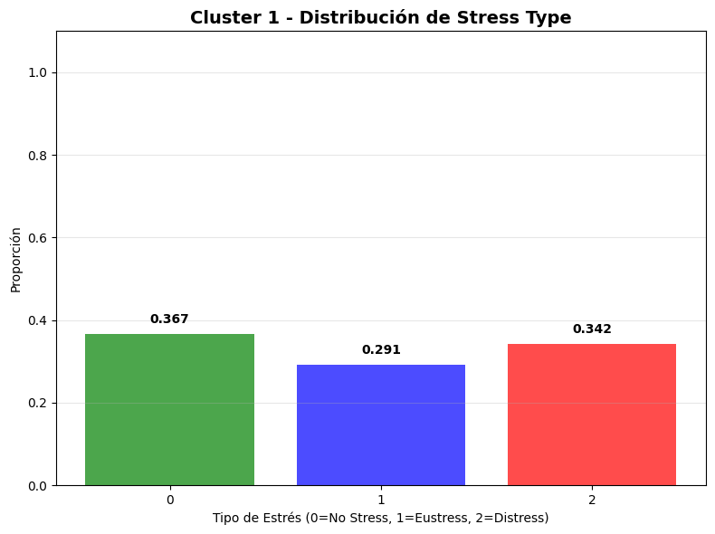

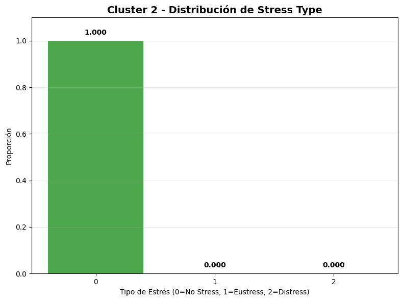

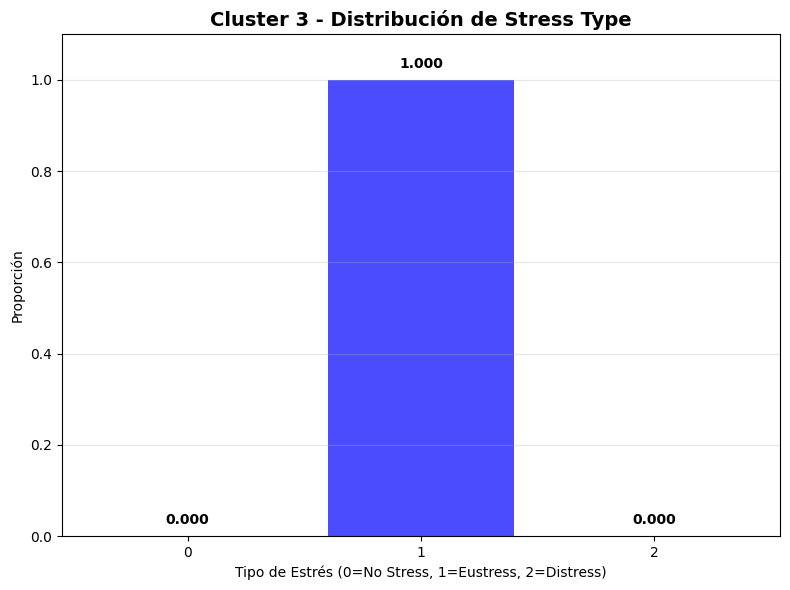

```python
def analisis_stress_level_por_cluster():
    # Preparar datos (usando el dataframe original con stress_level)
    df_analisis = df.copy()
    df_analisis['cluster'] = grupos_definitivos

    # Calcular proporciones
    tabla_contingencia = pd.crosstab(df_analisis['cluster'],
                                    df_analisis['stress_level'],
                                    normalize='index')

    # Crear un gráfico por cada cluster
    for cluster_num in range(4):
        plt.figure(figsize=(8, 6))

        # Datos del cluster actual
        datos_cluster = tabla_contingencia.loc[cluster_num]

        # Crear gráfico de barras
        barras = plt.bar(datos_cluster.index.astype(str), datos_cluster.values,
                        color=['green', 'blue', 'red'], alpha=0.7)

        plt.title(f'Cluster {cluster_num} - Distribución de Stress Type', fontsize=14, fontweight='bold')
        plt.xlabel('Tipo de Estrés (0=No Stress, 1=Eustress, 2=Distress)')
        plt.ylabel('Proporción')
        plt.ylim(0, 1.1)
        plt.grid(axis='y', alpha=0.3)

        # Añadir valores en las barras
        for i, valor in enumerate(datos_cluster.values):
            plt.text(i, valor + 0.02, f'{valor:.3f}', ha='center', va='bottom', fontweight='bold')

        plt.tight_layout()
        plt.show()

analisis_stress_level_por_cluster()
```

**Distribución de `stress_level` por cluster**

- Cluster 0:
  - Distress: 1
- Cluster 1:
  - **No Stress: 0.367**
  - Eustress: 0.291
  - Distress: 0.342
- Cluster 2:
  - No Stress: 1
- Cluster 3:
  - Eustress: 1

# Ejercicio 2

[30 puntos] Programe una clase en Python (estilo Pythónico) denominada CJ que tiene lo siguiente:

**Atributos:**

- `datos`: Un *data.frame* de Pandas con la Tabla de Datos.
- `num_cluster`: Número que indica la cantidad de clústeres a formar.
- `algoritmo`: Un string que indica el algoritmo a utilizar para calcular las distancias, pueden ser las siguientes: `euclidean`, `cityblock`, `canberra`, `cosine`, `chebyshev`, `minkowski`, `hamming`, `jaccard`, `pearson`, `braycurtis`, `mahalanobis`, `sqeuclidean`, `hellinger`, `kullback_leibler`.
- `agregacion`: Un string que indica el índice de agregación a utilizar para calcular las agregaciones. Pueden ser las siguientes: `ward`, `average`, `single`, `complete`.
- `matriz_distancias`: Un *array* que contiene las distancias.
- `matriz_agregaciones`: Un *array* que contiene las agregaciones necesarias para plotear en dendograma.
- `grupos`: Un vector *array* que contiene el cluster a que pertenece cada uno de los individuos.
- `centros`: Un *data.frame* que contiene el centro de gravedad (vectores con los promedios) de cada uno de los clústeres (que son necesarios para hacer los gráficos de barras y radar).

**Métodos:**

- `init` : El constructor debe recibir por parámetro los datos, la cantidad de clústeres a formar, el algoritmo a utilizar para calcular las distancias y la agregación a utilizar.
- `gets`: Todos los atributos deben tener un get.
- `sets`: Solo los atributos `datos`, `num_cluster`, `algoritmo` y `agregacion` deben tener método set.
- `datos cluster`: Retorna los datos junto con la columna que indica el cluster de cada individuo.
- `inercias`: Retorna en un diccionario: la inercia total, la inercia inter-clase y la inercia intra-clase.
- `grafico_barra`: Retorna el gráfico de barras con el valor promedio de cada variable según el cluster. Debe recibir por parámetro un valor booleano indicando si se quiere estandarizar los centros.
- `grafico_radar`: Retorna el gráfico radar con el valor promedio de cada variable según el cluster.

Luego, para verificar la correctitud de la clase programada, repita los ejercicios 1c), 1d), 1e) y 1f ).

↑ Volver al Menú

Luego, para verificar la correctitud de la clase programada, repita los ejercicios 1c), 1d), 1e) y 1f ).

```python
import pandas as pd
import numpy as np
import matplotlib.pyplot as plt
from scipy.spatial.distance import pdist
from scipy.cluster.hierarchy import linkage, fcluster
from sklearn.preprocessing import MinMaxScaler

class CJ:
# constructor
    def __init__(self, datos, num_cluster, algoritmo='euclidean', agregacion='ward'):
        self._datos = datos
        self._num_cluster = num_cluster
        self._algoritmo = algoritmo
        self._agregacion = agregacion
        self._matriz_distancias = None
        self._matriz_agregaciones = None
        self._grupos = None
        self._centros = None

        # Calcular automáticamente al inicializar
        self.__fit()

    def __fit(self):
        # Calcular matriz de distancias
        self._matriz_distancias = pdist(self._datos.values, metric=self._algoritmo)

        # Calcular matriz de agregaciones
        self._matriz_agregaciones = linkage(self._matriz_distancias, method=self._agregacion)

        # Obtener grupos y ajustar índices (0-indexed)
        self._grupos = fcluster(self._matriz_agregaciones, self._num_cluster, criterion='maxclust')
        self._grupos = self._grupos - 1  # Para que empiece en 0

        # Calcular centros
        datos_con_grupos = self._datos.copy()
        datos_con_grupos['cluster'] = self._grupos
        self._centros = datos_con_grupos.groupby('cluster').mean()

# getter
    def get_datos(self):
        return self._datos

    def get_num_cluster(self):
        return self._num_cluster

    def get_algoritmo(self):
        return self._algoritmo

    def get_agregacion(self):
        return self._agregacion

    def get_matriz_distancias(self):
        return self._matriz_distancias

    def get_matriz_agregaciones(self):
        return self._matriz_agregaciones

    def get_grupos(self):
        return self._grupos

    def get_centros(self):
        return self._centros

# settter
    def set_datos(self, nuevos_datos):
        self._datos = nuevos_datos
        self.__fit()

    def set_num_cluster(self, nuevo_num_cluster):
        self._num_cluster = nuevo_num_cluster
        self.__fit()

    def set_algoritmo(self, nuevo_algoritmo):
        self._algoritmo = nuevo_algoritmo
        self.__fit()

    def set_agregacion(self, nueva_agregacion):
        self._agregacion = nueva_agregacion
        self.__fit()

# methods
    def __inercia_total(self):
        promedios_total = self._datos.mean()
        inercia_total = 0
        for i in range(self._datos.shape[0]):
            inercia_total += np.sum((self._datos.iloc[i, :] - promedios_total) ** 2)
        return inercia_total

    def __inercia_intra_clase(self):
        intra_clase = 0
        for i in range(self._datos.shape[0]):
            intra_clase += np.sum((self._datos.iloc[i, :] - self._centros.iloc[self._grupos[i], :]) ** 2)
        return intra_clase

    def __inercia_inter_clase(self):
        promedios_total = self._datos.mean()
        inter_clase = 0
        for i in range(self._centros.shape[0]):
            n = np.sum(self._grupos == i)
            inter_clase += n * np.sum((promedios_total - self._centros.iloc[i, :]) ** 2)
        return inter_clase

    def inercias(self):
        return {
            'inercia_total': self.__inercia_total(),
            'inercia_intra': self.__inercia_intra_clase(),
            'inercia_inter': self.__inercia_inter_clase()
        }

    def datos_cluster(self):
        datos_con_cluster = self._datos.copy()
        datos_con_cluster['cluster'] = self._grupos
        return datos_con_cluster

    def grafico_barra(self, estandarizar=True):
        centros = self._centros.copy()

        if estandarizar:
            scaler = MinMaxScaler()
            centros = pd.DataFrame(
                scaler.fit_transform(centros),
                columns=centros.columns,
                index=centros.index
            )

        fig, ax = plt.subplots(figsize=(12, 8))
        centros.plot(kind='bar', ax=ax)

        ax.set_xlabel('Clúster', fontsize=12)
        ax.set_ylabel('Promedio' + (' (Estandarizado)' if estandarizar else ''), fontsize=12)
        ax.set_title(f'Centros de Clusters - {self._algoritmo} - {self._agregacion}')
        ax.legend(title="Factores", title_fontsize=13, fontsize=11, loc='upper right', bbox_to_anchor=(1.26, 1))

        plt.xticks(rotation=45)
        plt.tight_layout()
        return fig

    def grafico_radar(self):
        centros = self._centros.copy()
        scaler = MinMaxScaler()
        centros = pd.DataFrame(
            scaler.fit_transform(centros),
            columns=centros.columns,
            index=centros.index
        ) * 100  # Escalar a 0-100

        variables = centros.columns
        N = len(variables)
        theta = np.linspace(0, 2 * np.pi, N, endpoint=False)
        theta = np.concatenate([theta, [theta[0]]])

        fig, ax = plt.subplots(figsize=(8, 8), subplot_kw={"projection": "polar"})

        # Configuración del radar
        ax.set_theta_zero_location("N")
        ax.set_theta_direction(-1)
        ax.set_rlabel_position(90)
        ax.spines["polar"].set_zorder(1)
        ax.spines["polar"].set_color("lightgrey")

        for cluster_id in centros.index:
            valores = centros.loc[cluster_id, variables].values.tolist()
            valores += [valores[0]]
            ax.plot(theta, valores, linewidth=1.75, linestyle="solid",
                    label=f"Cluster {cluster_id}", marker="o", markersize=4)
            ax.fill(theta, valores, alpha=0.25)

        plt.yticks([0, 25, 50, 75, 100], ["0", "25", "50", "75", "100"], size=10)
        plt.ylim(-10, 100)
        plt.xticks(theta[:-1], variables, size=10)
        plt.legend(loc="upper right", bbox_to_anchor=(1.3, 1.0))
        plt.title(f'Radar de Clusters - {self._algoritmo} - {self._agregacion}')

        return fig

    def __str__(self):
        inercias = self.inercias()
        return (f"CJ - Clustering Jerárquico\n"
                f"--------------------------\n"
                f"Datos: {self._datos.shape[0]} individuos, {self._datos.shape[1]} variables\n"
                f"Clusters: {self._num_cluster}\n"
                f"Algoritmo: {self._algoritmo}\n"
                f"Agregación: {self._agregacion}\n"
                f"Inercia total: {inercias['inercia_total']:.2f}\n"
                f"Inercia inter: {inercias['inercia_inter']:.2f}\n"
                f"Inercia intra: {inercias['inercia_intra']:.2f}")
```

## Punto 1.C

Genere el Clustering Jerárquico con un número fijo de 4 clusters, utilizando:

- Tres tipos de distancia (por ejemplo: Euclidiana, Manhattan y Gower).
- Cuatro métodos de enlace (linkage): single, complete, average, ward.  
  En total deben generarse 12 modelos de clustering jerárquico.

```python
# parametros para los 12 modelos
distancias = ['euclidean', 'chebyshev', 'canberra']
agregaciones = ['single', 'complete', 'average', 'ward']
num_clusters = 4

# diccionario para almacenar los 12 modelos
modelos = {}

# 12 modelos sistemáticamente
for distancia in distancias:
  for agregacion in agregaciones:
    # Crear instancia del modelo CJ
    modelo = CJ(df_cod, num_clusters, distancia, agregacion)

    # Almacenar el modelo en el diccionario
    clave = f"{distancia}_{agregacion}"
    modelos[clave] = modelo

    # Calcular inercias para verificar que funciona
    inercias = modelo.inercias()
    porcentaje_explicado = (inercias['inercia_inter'] / inercias['inercia_total']) * 100
    # Buscar MÍNIMA inercia intra-clase (dentro del cluster), Buscar MÁXIMA inercia inter-clase (entre clusters)
    print(f"{distancia:11} | {agregacion:11} | inter_max: {inercias['inercia_inter']:.2f} - intra_min: {inercias['inercia_intra']:.2f} {'':4}| {porcentaje_explicado:.2f}%")
```

```
euclidean   | single      | inter_max: 1288.97 - intra_min: 227155.48     | 0.56%
euclidean   | complete    | inter_max: 140713.76 - intra_min: 87730.69     | 61.60%
euclidean   | average     | inter_max: 139473.52 - intra_min: 88970.93     | 61.05%
euclidean   | ward        | inter_max: 168445.97 - intra_min: 59998.48     | 73.74%
chebyshev   | single      | inter_max: 0.00 - intra_min: 228444.45     | 0.00%
chebyshev   | complete    | inter_max: 142926.58 - intra_min: 85517.87     | 62.57%
chebyshev   | average     | inter_max: 143822.97 - intra_min: 84621.48     | 62.96%
chebyshev   | ward        | inter_max: 170220.21 - intra_min: 58224.24     | 74.51%
canberra    | single      | inter_max: 857.46 - intra_min: 227586.99     | 0.38%
canberra    | complete    | inter_max: 129717.83 - intra_min: 98726.62     | 56.78%
canberra    | average     | inter_max: 95343.04 - intra_min: 133101.41     | 41.74%
canberra    | ward        | inter_max: 152756.89 - intra_min: 75687.56     | 66.87%
```

## Punto 1.D

Para cada uno de los 12 modelos de Clustering Jerárquico formados anteriormente seleccione la mejor formación según la inercia (intra-clase o inter-clase).

El mejor modelo de los 12 seria el:  
euclidean | ward | inter_max: 168445.97 - intra_min: 59998.48 | 73.74%  
El metodo Ward es muy efectivo para crear clusteres compactos y bien separados entre si.  
Chebyshev con Ward tiene un porcentaje de inercia inter-clase ligeramente superior (74.51%), Euclidean con Ward (73.74%) es una opción más común y robusta en la mayoría de los casos, especialmente si las variables no están en la misma escala, ya que la distancia euclídea considera todas las dimensiones.

## Punto 1.E

Brinde una característica de cada cluster utilizando el gráfico de barras.

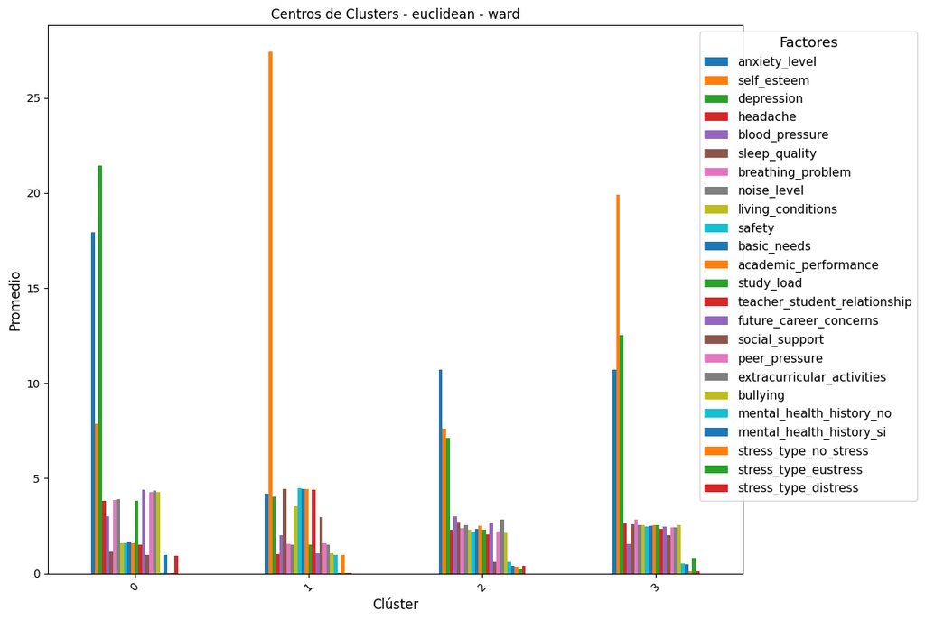

```python
modelo = CJ(df_cod, num_cluster=4, algoritmo='euclidean', agregacion='ward')
figura = modelo.grafico_barra(estandarizar=False)
plt.show()
```

Características de cada cluster:

- Cluster 0:  
  • Variable más alta: `depression`  
  • Variable más baja: `stress_type_no_stress`
- Cluster 1:  
  • Variable más alta: `self_esteem`  
  • Variable más baja: `stress_type_eustress`
- Cluster 2:  
  • Variable más alta: `anxiety_level`  
  • Variable más baja: `stress_type_eustress`
- Cluster 3:  
  • Variable más alta: `self_esteem`  
  • Variable más baja: `stress_type_distress`

## Punto 1.F

Brinde una característica de cada cluster utilizando el gráfico radar.

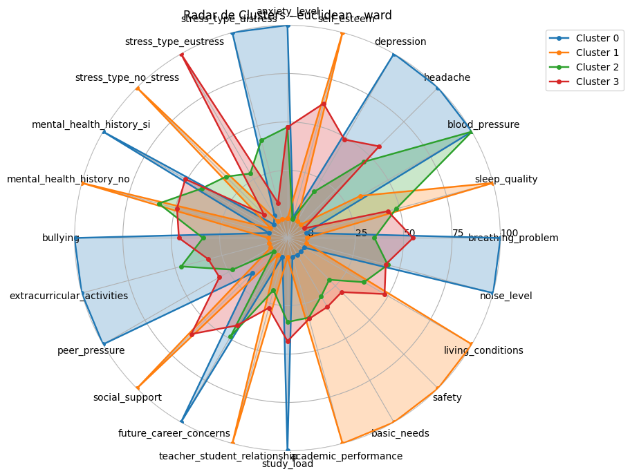

```python
modelo = CJ(df_cod, num_cluster=4, algoritmo='euclidean', agregacion='ward')
figura = modelo.grafico_radar()
plt.show()
```